# q1

JD

2024-11-23

#loading required libraries

```r
library(dada2)
```

```r
library(ggplot2)
library(phyloseq)
library(RColorBrewer)
```

#Set my working directory for these data

```r
path<-setwd("C:/Users/jibin/newunix/project 3")
#made an object "path"
#listing all the files in path
list.files(path)
```

```
##  [1] "000010.png"
##  [2] "000012.png"
##  [3] "envs6452_2024_ampliconscript--1-.Rmd"
##  [4] "envs6452_2024_ampliconscript (1).Rmd"
##  [5] "envs6452_2024_ampliconscript.Rmd"
##  [6] "filtered"
##  [7] "flipped_seqtab.nochim.csv"
##  [8] "orderfinal.html"
##  [9] "orderfinal.Rmd"
## [10] "OTUabund.csv"
## [11] "P1_S196_L001_R1_001.fastq"
## [12] "P1_S196_L001_R2_001.fastq"
## [13] "phylum_relabund.Rmd"
## [14] "q1_final.png"
## [15] "q4.png"
## [16] "RplotOrder.png"
## [17] "seqtab.nochim.csv"
## [18] "silva_nr99_v138.1_train_set.fa.gz"
## [19] "silva_species_assignment_v138.1.fa"
## [20] "taxa.csv"
## [21] "track.csv"
## [22] "Wneg_S279_L001_R1_001.fastq"
## [23] "Wneg_S279_L001_R2_001.fastq"
```

# List and sort files

```r
fnFs <- sort(list.files(path, pattern = "_R1_001.fastq", full.names = TRUE))
fnRs <- sort(list.files(path, pattern = "_R2_001.fastq", full.names = TRUE))
```

# Extract sample names

```r
sample.names <- sapply(strsplit(basename(fnFs), "_"), `[`, 1)
print(sample.names)
```

```
## [1] "P1"   "Wneg"
```

#visualize the quality profile of forward and reverse reads:

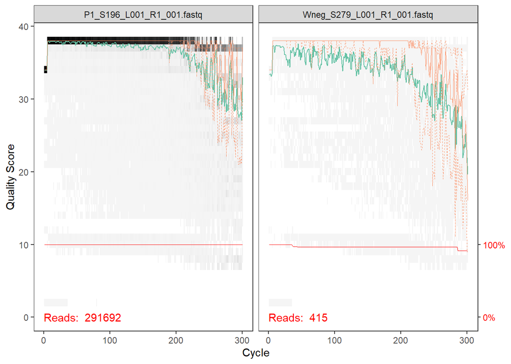

```r
plotQualityProfile(fnFs[1:2])
```

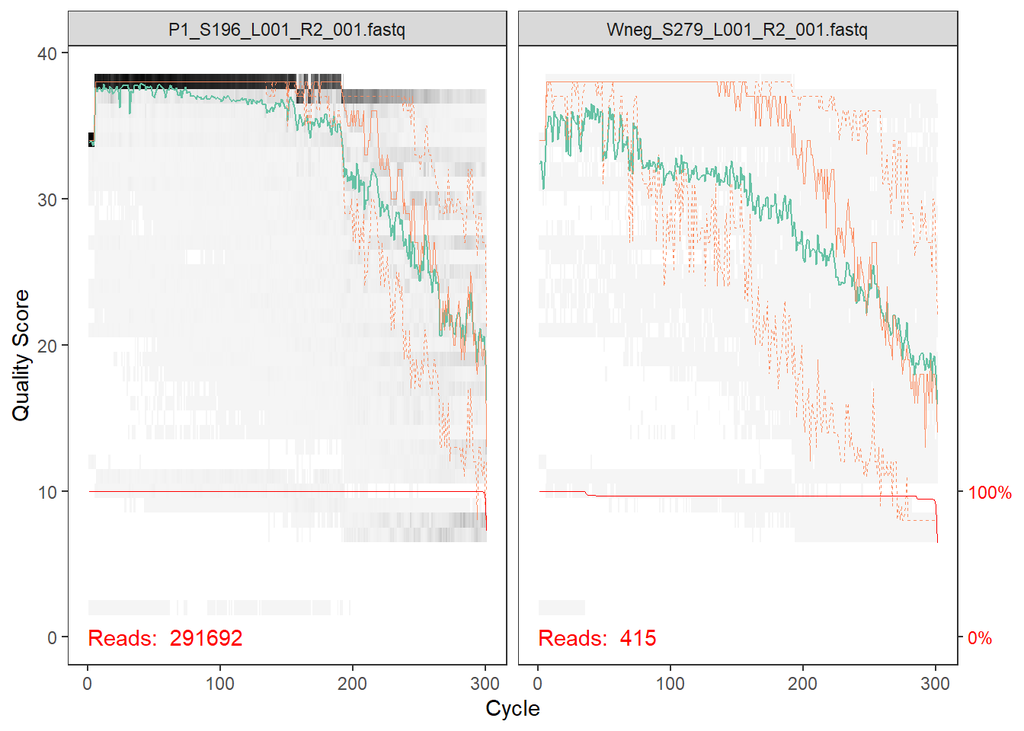

```r
plotQualityProfile(fnRs[1:2])
```

```r
# Place filtered files in filtered/ subdirectory
filtFs <- file.path(path, "filtered", paste0(sample.names, "_F_filt.fastq.gz"))
filtRs <- file.path(path, "filtered", paste0(sample.names, "_R_filt.fastq.gz"))
names(filtFs) <- sample.names
names(filtRs) <- sample.names
```

#filter and trim

```r
out <- filterAndTrim(fnFs, filtFs, fnRs, filtRs, truncLen=c(250,180),
              maxN=0, maxEE=c(2,2), truncQ=2, rm.phix=TRUE,
              compress=TRUE, multithread=TRUE) # On Windows set multithread=FALSE
```

```
## Multithreading has been DISABLED, as forking is not supported on .Platform$OS.type 'windows'
```

```r
head(out)
```

```
##                             reads.in reads.out
## P1_S196_L001_R1_001.fastq     291692    272738
## Wneg_S279_L001_R1_001.fastq      415       257
```

```r
# Learn the error rates for forward and reverse reads
errF <- learnErrors(filtFs, multithread = TRUE)  # Forward reads
```

```
## 68248750 total bases in 272995 reads from 2 samples will be used for learning the error rates.
```

```r
errR <- learnErrors(filtRs, multithread = TRUE)  # Reverse reads
```

```
## 49139100 total bases in 272995 reads from 2 samples will be used for learning the error rates.
```

#visualising error rates plotErrors(errF, nominalQ=TRUE)

# Apply denoising to the forward and reverse reads

```r
dadaFs <- dada(filtFs, err = errF, multithread = TRUE)
```

```
## Sample 1 - 272738 reads in 49388 unique sequences.
## Sample 2 - 257 reads in 156 unique sequences.
```

```r
dadaRs <- dada(filtRs, err = errR, multithread = TRUE)
```

```
## Sample 1 - 272738 reads in 49250 unique sequences.
## Sample 2 - 257 reads in 147 unique sequences.
```

dadaFs[[1]]

```r
#We now merge the forward and reverse reads together to obtain the full denoised sequences.
mergers <- mergePairs(dadaFs, filtFs, dadaRs, filtRs, verbose=TRUE)
```

```
## 254219 paired-reads (in 12010 unique pairings) successfully merged out of 264148 (in 16331 pairings) input.
```

```
## 29 paired-reads (in 4 unique pairings) successfully merged out of 191 (in 7 pairings) input.
```

#inspecting head(mergers[[1]])

```r
#combine all merged sequences across all samples into a sequence table
seqtab <- makeSequenceTable(mergers)
dim(seqtab)  # Check dimensions (samples x ASVs)
```

```
## [1]     2 12014
```

# Inspect distribution of sequence lengths

table(nchar(getSequences(seqtab)))

```r
#remove chimeras
seqtab.nochim <- removeBimeraDenovo(seqtab, method="consensus", multithread=TRUE, verbose=TRUE)
```

```
## Identified 9502 bimeras out of 12014 input sequences.
```

```r
dim(seqtab.nochim)
```

```
## [1]    2 2512
```

```r
#As a final check of our progress, we’ll look at the number of reads that made it through each step in the pipeline:

getN <- function(x) sum(getUniques(x))
track <- cbind(out, sapply(dadaFs, getN), sapply(dadaRs, getN), sapply(mergers, getN), rowSums(seqtab.nochim))
# If processing a single sample, remove the sapply calls: e.g. replace sapply(dadaFs, getN) with getN(dadaFs)
colnames(track) <- c("input", "filtered", "denoisedF", "denoisedR", "merged", "nonchim")
rownames(track) <- sample.names
head(track)
```

```
##       input filtered denoisedF denoisedR merged nonchim
## P1   291692   272738    268222    268126 254219  114692
## Wneg    415      257       198       212     29      29
```

#assigning taxonomy #download database from SILVA: https://www.arb-silva.de/ and keep it in the wdirectory

```r
taxa <- assignTaxonomy(seqtab.nochim, "silva_nr99_v138.1_train_set.fa.gz", multithread=TRUE)
```

```r
#saving as we go for break hehe
write.csv(taxa,file = "C:/Users/jibin/newunix/project 3/taxa.csv")
write.csv(seqtab.nochim, file = "C:/Users/jibin/newunix/project 3/seqtab.nochim.csv")
write.csv(track, file = "C:/Users/jibin/newunix/project 3/track.csv")
```

```r
##Rest of script is handing off to phyloseq, and assumes you are starting from files saved on your computer
taxa <- read.csv("C:/Users/jibin/newunix/project 3/taxa.csv")
seqtab.nochim <- read.csv("C:/Users/jibin/newunix/project 3/seqtab.nochim.csv",header=FALSE)
```

#transpose the sequence table

```r
flipped_seqtab.nochim <- as.data.frame(t(seqtab.nochim))
#The first row of flipped_seqtab.nochim (sample names) is set as column names.
#Then, you remove the first row since it’s no longer needed.
```

```r
colnames(flipped_seqtab.nochim) <- flipped_seqtab.nochim[1,]
# Set the first row as column names
flipped_seqtab.nochim <- flipped_seqtab.nochim[-1,]
# Remove the first row
```

```r
#Next we want to change the names of the sequences to "ASVS" ( bc it looks nice)
rownames(flipped_seqtab.nochim) <- paste0("ASV", 1:nrow(flipped_seqtab.nochim))
#and remove the sequences column:
flipped_seqtab.nochim<- flipped_seqtab.nochim[,-1]
```

```r
#save this transposed file in case it is useful later, it looks nice now.
write.csv(flipped_seqtab.nochim, file = "C:/Users/jibin/newunix/project 3/flipped_seqtab.nochim.csv")
```

```r
#Combine ASV Table and Taxonomy Data
#This step merges the abundance table (flipped_seqtab.nochim) with the taxonomy (taxa), creating a combined dataset.
OTUabund <- cbind(flipped_seqtab.nochim, taxa)
write.csv(OTUabund, file = "C:/Users/jibin/newunix/project 3/OTUabund.csv")
```

#now that we have that file made, we will change our taxa dataframe to be compatible with the taxa file format for Phyloseq ( which is to say - it doesnt list the ASVs or sequences in its first column). Check your taxa file before and after this step. It will ( should) have the sequences as the first column before, and have them removed after

```r
taxa<-taxa[-1]
```

```r
taxmat <- as.matrix(taxa)
otumat <-as.matrix(flipped_seqtab.nochim)
#Check to make sure this looks like what you expect.
```

```r
#Lets make sure our files are matrices:
#first convert to matrix
otumat <- as.matrix(otumat)
taxmat <-as.matrix(taxmat)

#then inspect ( Want it do show its a matrix array)
class(otumat)
```

```
## [1] "matrix" "array"
```

```r
class(taxmat)
```

```
## [1] "matrix" "array"
```

```r
#then make sure the rownames for both files are the same and labelled by ASV
rownames(otumat) <- paste0("ASV", 1:nrow(otumat))
rownames(taxmat) <- paste0("ASV", 1:nrow(otumat))

#then make sure that R recognizes that the OTU data is numeric, not character data
class(otumat)<-"numeric"
```

#If we now have matrices…we’re in business #These are phyloseq specific commands. You dont need to know all of them ( but suggest reading the manual if you use this script often). We are telling phyloseq where our “OTUs” and “Taxa” files are. Phyloseq was built at a time when OTUs were popular….but it works for ASVs too ( obviously)

#tell phyloseq where our ASVs are

```r
OTU = otu_table(otumat, taxa_are_rows = TRUE)
```

#tell phyloseq where our taxa are

```r
TAX = tax_table(taxmat)
```

#now we tell phyloseq to put it all together ( sample names, OTU and taxa)

```r
physeq = phyloseq(OTU, TAX)
physeq
```

```
## phyloseq-class experiment-level object
## otu_table()   OTU Table:         [ 2512 taxa and 2 samples ]
## tax_table()   Taxonomy Table:    [ 2512 taxa by 6 taxonomic ranks ]
```

```r
sample_names(physeq)
```

```
## [1] "P1"   "Wneg"
```

```r
samplenames<-sample_names(physeq)
```

#Finally our first graph!

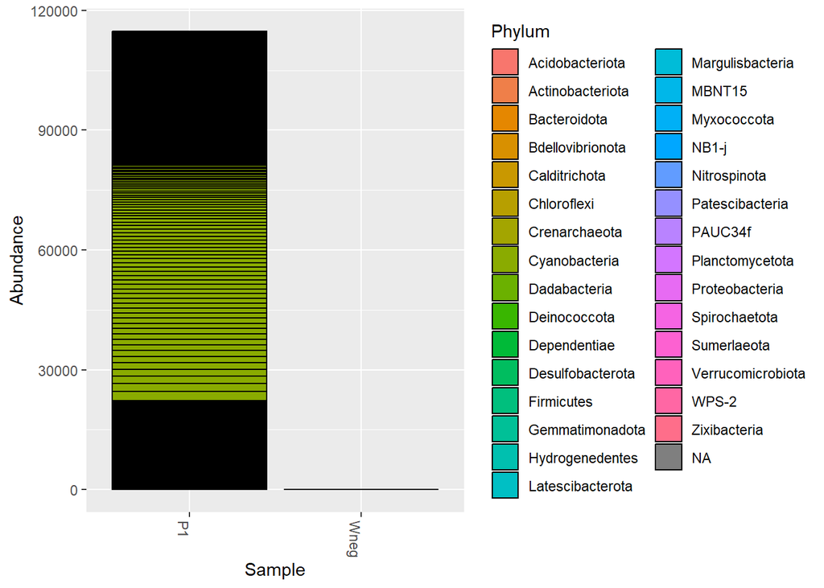

```r
p<-plot_bar(physeq, fill = "Phylum")
p
```

```r
#note, if you want this to show in your plot pane, make sure you enter this code in your console, not just in your script.
```

##This is an OK start, but I dont like the lines that represent each ASV. Lets first try a graph that removes them

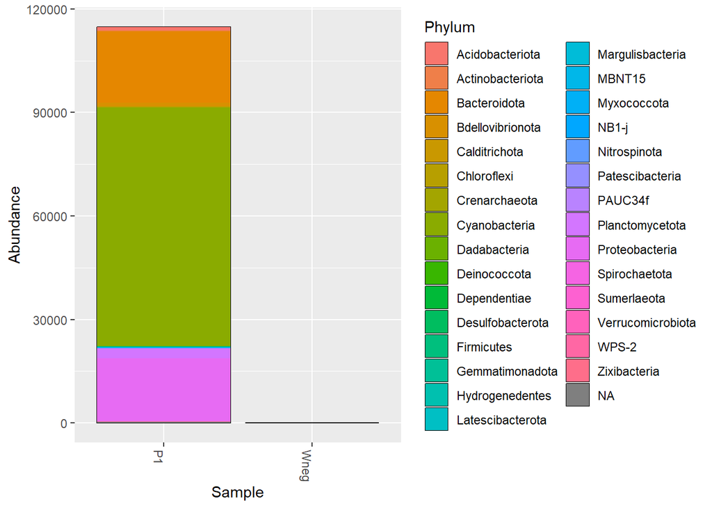

```r
pstacked<- p + geom_bar(aes(fill=Phylum), stat="identity", position="stack")
pstacked
```

#ok this looks MUCH better! While its nice that I can see absolute numbers of sequences, I would like to see relative abunbdance ( % abundance). We can do that AND use ggplot ( always look nicer) with a few steps….

#First - we use the “tax_glom” of phyloseq to glom together taxa based on the column of your choosing. Here I will do it by Phylum. Pay attention to how I choose the Phylum column….

```r
ps_phylum <- tax_glom(physeq, "Phylum")
```

#note - we can also use this glom function to glom together taxa for graphing! ( instead of “identity=stacked”) Theres always multiple ways to do things in R.

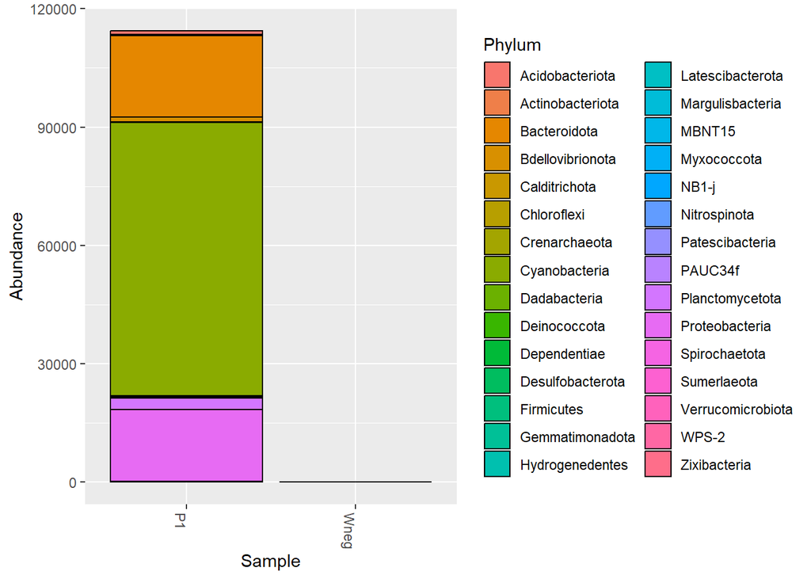

```r
plot_bar(ps_phylum, fill = "Phylum")
```

#after we glom together our taxa by Phylum, we will make a table of relative abundance by tallying up each taxa, and dividing by the total taxa ( eg. what percentage of the total is each phylum in each sample). Again, note where I am specifying the column I am interested in (“Phylum”). Reflect on –> What would you change if you wanted to do something similar but for “Family”?

```r
ps_phylum_relabun <- transform_sample_counts(ps_phylum, function(ASV) ASV/sum(ASV))
```

```r
taxa_abundance_table_phylum <- psmelt(ps_phylum_relabun)
taxa_abundance_table_phylum$Phylum<-factor(taxa_abundance_table_phylum$Phylum)
```

```r
p_ra <- plot_bar(ps_phylum_relabun, fill = "Phylum") +
  labs(
    title = "Relative Abundance of Phyla in Pumice and Negative Control Samples",
    x = "Samples",
    y = "Relative Abundance"
  ) +
  theme_minimal()
```